# Risk Factor Analysis

## Outcome Variable

**Outcome Variable:** sstunted

## Predictor Variables

**Intervention Variable:** birthwt

**Adjustment Set:**

unadjusted

## Stratifying Variables

The analysis was stratified on these variable(s):

- agecat
- studyid

The following strata were considered:

- agecat: 12 months, studyid: ki0047075b-MAL-ED
- agecat: 12 months, studyid: ki1000108-CMC-V-BCS-2002
- agecat: 12 months, studyid: ki1000108-IRC
- agecat: 12 months, studyid: ki1000109-EE
- agecat: 12 months, studyid: ki1017093b-PROVIDE
- agecat: 12 months, studyid: ki1017093c-NIH-Crypto
- agecat: 12 months, studyid: ki1066203-TanzaniaChild2
- agecat: 12 months, studyid: ki1101329-Keneba
- agecat: 12 months, studyid: ki1126311-ZVITAMBO
- agecat: 12 months, studyid: ki1135781-COHORTS
- agecat: 18 months, studyid: ki0047075b-MAL-ED
- agecat: 18 months, studyid: ki1000108-CMC-V-BCS-2002
- agecat: 18 months, studyid: ki1000108-IRC
- agecat: 18 months, studyid: ki1000109-EE
- agecat: 18 months, studyid: ki1017093b-PROVIDE
- agecat: 18 months, studyid: ki1017093c-NIH-Crypto
- agecat: 18 months, studyid: ki1066203-TanzaniaChild2
- agecat: 18 months, studyid: ki1101329-Keneba
- agecat: 18 months, studyid: ki1126311-ZVITAMBO
- agecat: 18 months, studyid: ki1135781-COHORTS
- agecat: 24 months, studyid: ki0047075b-MAL-ED
- agecat: 24 months, studyid: ki1000108-CMC-V-BCS-2002
- agecat: 24 months, studyid: ki1000108-IRC
- agecat: 24 months, studyid: ki1017093b-PROVIDE
- agecat: 24 months, studyid: ki1017093c-NIH-Crypto
- agecat: 24 months, studyid: ki1066203-TanzaniaChild2
- agecat: 24 months, studyid: ki1101329-Keneba
- agecat: 24 months, studyid: ki1126311-ZVITAMBO
- agecat: 24 months, studyid: ki1135781-COHORTS
- agecat: 3 months, studyid: ki0047075b-MAL-ED
- agecat: 3 months, studyid: ki1000108-CMC-V-BCS-2002
- agecat: 3 months, studyid: ki1000108-IRC
- agecat: 3 months, studyid: ki1000109-EE
- agecat: 3 months, studyid: ki1017093b-PROVIDE
- agecat: 3 months, studyid: ki1017093c-NIH-Crypto
- agecat: 3 months, studyid: ki1066203-TanzaniaChild2
- agecat: 3 months, studyid: ki1101329-Keneba
- agecat: 3 months, studyid: ki1126311-ZVITAMBO
- agecat: 3 months, studyid: ki1135781-COHORTS
- agecat: 6 months, studyid: ki0047075b-MAL-ED
- agecat: 6 months, studyid: ki1000108-CMC-V-BCS-2002
- agecat: 6 months, studyid: ki1000108-IRC
- agecat: 6 months, studyid: ki1000109-EE
- agecat: 6 months, studyid: ki1017093b-PROVIDE
- agecat: 6 months, studyid: ki1017093c-NIH-Crypto
- agecat: 6 months, studyid: ki1066203-TanzaniaChild2
- agecat: 6 months, studyid: ki1101329-Keneba
- agecat: 6 months, studyid: ki1126311-ZVITAMBO
- agecat: 6 months, studyid: ki1135781-COHORTS
- agecat: 9 months, studyid: ki0047075b-MAL-ED
- agecat: 9 months, studyid: ki1000108-CMC-V-BCS-2002
- agecat: 9 months, studyid: ki1000108-IRC
- agecat: 9 months, studyid: ki1000109-EE
- agecat: 9 months, studyid: ki1017093b-PROVIDE
- agecat: 9 months, studyid: ki1017093c-NIH-Crypto
- agecat: 9 months, studyid: ki1066203-TanzaniaChild2
- agecat: 9 months, studyid: ki1101329-Keneba
- agecat: 9 months, studyid: ki1126311-ZVITAMBO
- agecat: 9 months, studyid: ki1135781-COHORTS
- agecat: Birth, studyid: ki0047075b-MAL-ED
- agecat: Birth, studyid: ki1000108-CMC-V-BCS-2002
- agecat: Birth, studyid: ki1000108-IRC
- agecat: Birth, studyid: ki1000109-EE
- agecat: Birth, studyid: ki1017093c-NIH-Crypto
- agecat: Birth, studyid: ki1101329-Keneba
- agecat: Birth, studyid: ki1126311-ZVITAMBO
- agecat: Birth, studyid: ki1135781-COHORTS

### Dropped Strata

Some strata were dropped due to rare outcomes:

- agecat: Birth, studyid: ki0047075b-MAL-ED
- agecat: Birth, studyid: ki1000108-CMC-V-BCS-2002
- agecat: Birth, studyid: ki1000108-IRC
- agecat: Birth, studyid: ki1000109-EE
- agecat: Birth, studyid: ki1017093c-NIH-Crypto
- agecat: Birth, studyid: ki1101329-Keneba
- agecat: Birth, studyid: ki1135781-COHORTS
- agecat: 3 months, studyid: ki0047075b-MAL-ED
- agecat: 3 months, studyid: ki1000108-CMC-V-BCS-2002
- agecat: 3 months, studyid: ki1000108-IRC
- agecat: 3 months, studyid: ki1000109-EE
- agecat: 3 months, studyid: ki1017093b-PROVIDE
- agecat: 3 months, studyid: ki1017093c-NIH-Crypto
- agecat: 3 months, studyid: ki1066203-TanzaniaChild2
- agecat: 3 months, studyid: ki1101329-Keneba
- agecat: 3 months, studyid: ki1135781-COHORTS
- agecat: 6 months, studyid: ki0047075b-MAL-ED
- agecat: 6 months, studyid: ki1000108-CMC-V-BCS-2002
- agecat: 6 months, studyid: ki1000108-IRC
- agecat: 6 months, studyid: ki1000109-EE
- agecat: 6 months, studyid: ki1017093b-PROVIDE
- agecat: 6 months, studyid: ki1017093c-NIH-Crypto
- agecat: 6 months, studyid: ki1066203-TanzaniaChild2
- agecat: 9 months, studyid: ki0047075b-MAL-ED
- agecat: 9 months, studyid: ki1000108-IRC
- agecat: 9 months, studyid: ki1000109-EE
- agecat: 9 months, studyid: ki1017093b-PROVIDE
- agecat: 9 months, studyid: ki1017093c-NIH-Crypto
- agecat: 9 months, studyid: ki1066203-TanzaniaChild2
- agecat: 12 months, studyid: ki1000108-IRC
- agecat: 12 months, studyid: ki1000109-EE
- agecat: 12 months, studyid: ki1017093b-PROVIDE
- agecat: 12 months, studyid: ki1017093c-NIH-Crypto
- agecat: 12 months, studyid: ki1066203-TanzaniaChild2
- agecat: 18 months, studyid: ki1000108-IRC
- agecat: 18 months, studyid: ki1017093b-PROVIDE
- agecat: 18 months, studyid: ki1017093c-NIH-Crypto
- agecat: 18 months, studyid: ki1066203-TanzaniaChild2
- agecat: 24 months, studyid: ki1000108-IRC
- agecat: 24 months, studyid: ki1017093b-PROVIDE
- agecat: 24 months, studyid: ki1017093c-NIH-Crypto
- agecat: 24 months, studyid: ki1066203-TanzaniaChild2
- agecat: 24 months, studyid: ki1126311-ZVITAMBO

## Methods Detail

We’re interested in the causal parameters $E[Y_a]$ for all values of $a \in \mathcal{A}$. These parameters represent the mean outcome if, possibly contrary to fact, we intervened to set all units to have $A=a$. Under the randomization and positivity assumptions, these are identified by the statistical parameters $\psi_a=E_W[E_{Y|A,W}(Y|A=a,W)]$. In addition, we’re interested in the mean of $Y$, $E[Y]$ under no intervention (the observed mean). We will estimate these parameters by using SuperLearner to fit the relevant likelihood factors – $E_{Y|A,W}(Y|A=a,W)$ and $p(A=a|W)$, and then updating our likelihood fit using a joint TMLE.

For unadjusted analyses ($W=\{\}$), initial likelihoods were estimated using Lrnr_glm to estimate the simple $E(Y|A)$ and Lrnr_mean to estimate $p(A)$. For adjusted analyses, a small library containing Lrnr_glmnet, Lrnr_xgboost, and Lrnr_mean was used.

Having estimated these parameters, we will then use the delta method to estimate relative risks and attributable risks relative to a prespecified baseline level of $A$.

# Results Detail

## Results Plots

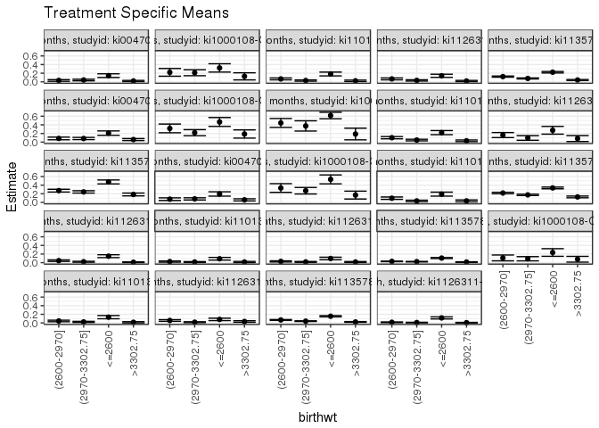

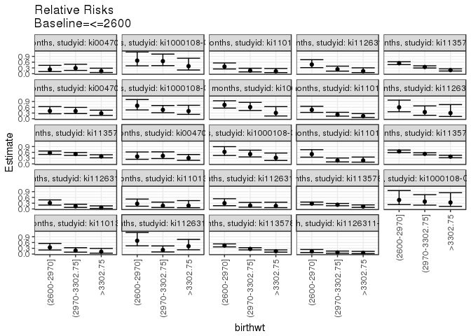

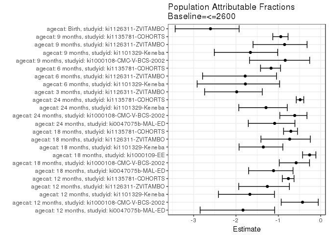

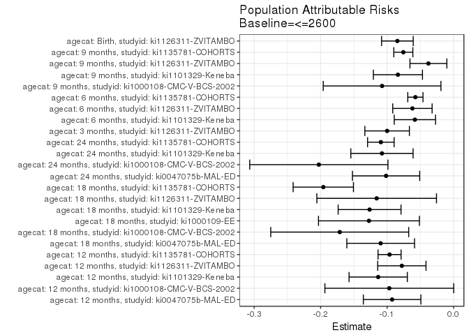

## Data Summary

| agecat | studyid | A | n | nA | nAY0 | nAY1 |
| --- | --- | --- | --- | --- | --- | --- |
| Birth | ki0047075b-MAL-ED | <=2600 | 1486 | 261 | 237 | 24 |
| Birth | ki0047075b-MAL-ED | (2600-2970] | 1486 | 328 | 320 | 8 |
| Birth | ki0047075b-MAL-ED | (2970-3302.75] | 1486 | 481 | 480 | 1 |
| Birth | ki0047075b-MAL-ED | >3302.75 | 1486 | 416 | 414 | 2 |
| Birth | ki1000108-CMC-V-BCS-2002 | <=2600 | 90 | 28 | 27 | 1 |
| Birth | ki1000108-CMC-V-BCS-2002 | (2600-2970] | 90 | 23 | 22 | 1 |
| Birth | ki1000108-CMC-V-BCS-2002 | (2970-3302.75] | 90 | 28 | 27 | 1 |
| Birth | ki1000108-CMC-V-BCS-2002 | >3302.75 | 90 | 11 | 11 | 0 |
| Birth | ki1000108-IRC | <=2600 | 383 | 98 | 90 | 8 |
| Birth | ki1000108-IRC | (2600-2970] | 383 | 114 | 111 | 3 |
| Birth | ki1000108-IRC | (2970-3302.75] | 383 | 113 | 108 | 5 |
| Birth | ki1000108-IRC | >3302.75 | 383 | 58 | 58 | 0 |
| Birth | ki1000109-EE | <=2600 | 2 | 1 | 1 | 0 |
| Birth | ki1000109-EE | (2600-2970] | 2 | 1 | 1 | 0 |
| Birth | ki1000109-EE | (2970-3302.75] | 2 | 0 | 0 | 0 |
| Birth | ki1000109-EE | >3302.75 | 2 | 0 | 0 | 0 |
| Birth | ki1017093b-PROVIDE | <=2600 | 0 | 0 | 0 | 0 |
| Birth | ki1017093b-PROVIDE | (2600-2970] | 0 | 0 | 0 | 0 |
| Birth | ki1017093b-PROVIDE | (2970-3302.75] | 0 | 0 | 0 | 0 |
| Birth | ki1017093b-PROVIDE | >3302.75 | 0 | 0 | 0 | 0 |
| Birth | ki1017093c-NIH-Crypto | <=2600 | 27 | 10 | 9 | 1 |
| Birth | ki1017093c-NIH-Crypto | (2600-2970] | 27 | 9 | 9 | 0 |
| Birth | ki1017093c-NIH-Crypto | (2970-3302.75] | 27 | 8 | 8 | 0 |
| Birth | ki1017093c-NIH-Crypto | >3302.75 | 27 | 0 | 0 | 0 |
| Birth | ki1066203-TanzaniaChild2 | <=2600 | 0 | 0 | 0 | 0 |
| Birth | ki1066203-TanzaniaChild2 | (2600-2970] | 0 | 0 | 0 | 0 |
| Birth | ki1066203-TanzaniaChild2 | (2970-3302.75] | 0 | 0 | 0 | 0 |
| Birth | ki1066203-TanzaniaChild2 | >3302.75 | 0 | 0 | 0 | 0 |
| Birth | ki1101329-Keneba | <=2600 | 1527 | 293 | 281 | 12 |
| Birth | ki1101329-Keneba | (2600-2970] | 1527 | 491 | 477 | 14 |

[output cut: 250 more lines]

## Results Table

### Parameter: TSM

| agecat | studyid | intervention_level | baseline_level | estimate | ci_lower | ci_upper |
| --- | --- | --- | --- | --- | --- | --- |
| Birth | ki1126311-ZVITAMBO | <=2600 | NA | 0.1169757 | 0.0931807 | 0.1407708 |
| Birth | ki1126311-ZVITAMBO | (2600-2970] | NA | 0.0160600 | 0.0079970 | 0.0241229 |
| Birth | ki1126311-ZVITAMBO | (2970-3302.75] | NA | 0.0094518 | 0.0036205 | 0.0152831 |
| Birth | ki1126311-ZVITAMBO | >3302.75 | NA | 0.0066138 | 0.0008350 | 0.0123925 |
| 3 months | ki1126311-ZVITAMBO | <=2600 | NA | 0.1503417 | 0.1169011 | 0.1837823 |
| 3 months | ki1126311-ZVITAMBO | (2600-2970] | NA | 0.0463576 | 0.0295858 | 0.0631294 |
| 3 months | ki1126311-ZVITAMBO | (2970-3302.75] | NA | 0.0212766 | 0.0106222 | 0.0319310 |
| 3 months | ki1126311-ZVITAMBO | >3302.75 | NA | 0.0097276 | 0.0012408 | 0.0182144 |
| 6 months | ki1101329-Keneba | <=2600 | NA | 0.0909091 | 0.0598831 | 0.1219351 |
| 6 months | ki1101329-Keneba | (2600-2970] | NA | 0.0247148 | 0.0114431 | 0.0379865 |
| 6 months | ki1101329-Keneba | (2970-3302.75] | NA | 0.0150094 | 0.0046839 | 0.0253348 |
| 6 months | ki1101329-Keneba | >3302.75 | NA | 0.0155280 | 0.0020195 | 0.0290364 |
| 6 months | ki1126311-ZVITAMBO | <=2600 | NA | 0.0966057 | 0.0670123 | 0.1261992 |
| 6 months | ki1126311-ZVITAMBO | (2600-2970] | NA | 0.0289855 | 0.0149868 | 0.0429842 |
| 6 months | ki1126311-ZVITAMBO | (2970-3302.75] | NA | 0.0169492 | 0.0070158 | 0.0268825 |
| 6 months | ki1126311-ZVITAMBO | >3302.75 | NA | 0.0151844 | 0.0040188 | 0.0263499 |
| 6 months | ki1135781-COHORTS | <=2600 | NA | 0.1064436 | 0.0950380 | 0.1178491 |
| 6 months | ki1135781-COHORTS | (2600-2970] | NA | 0.0298565 | 0.0232878 | 0.0364253 |
| 6 months | ki1135781-COHORTS | (2970-3302.75] | NA | 0.0233940 | 0.0176849 | 0.0291031 |
| 6 months | ki1135781-COHORTS | >3302.75 | NA | 0.0139230 | 0.0073504 | 0.0204956 |
| 9 months | ki1000108-CMC-V-BCS-2002 | <=2600 | NA | 0.2359551 | 0.1476224 | 0.3242877 |
| 9 months | ki1000108-CMC-V-BCS-2002 | (2600-2970] | NA | 0.1097561 | 0.0420069 | 0.1775053 |
| 9 months | ki1000108-CMC-V-BCS-2002 | (2970-3302.75] | NA | 0.0909091 | 0.0417999 | 0.1400183 |
| 9 months | ki1000108-CMC-V-BCS-2002 | >3302.75 | NA | 0.0793651 | 0.0125260 | 0.1462041 |
| 9 months | ki1101329-Keneba | <=2600 | NA | 0.1341463 | 0.0972528 | 0.1710399 |
| 9 months | ki1101329-Keneba | (2600-2970] | NA | 0.0459770 | 0.0280053 | 0.0639487 |
| 9 months | ki1101329-Keneba | (2970-3302.75] | NA | 0.0241636 | 0.0111842 | 0.0371429 |
| 9 months | ki1101329-Keneba | >3302.75 | NA | 0.0157729 | 0.0020530 | 0.0294927 |
| 9 months | ki1126311-ZVITAMBO | <=2600 | NA | 0.0822281 | 0.0544907 | 0.1099655 |
| 9 months | ki1126311-ZVITAMBO | (2600-2970] | NA | 0.0569853 | 0.0375003 | 0.0764703 |

[output cut: 66 more lines]

### Parameter: E(Y)

| agecat | studyid | intervention_level | baseline_level | estimate | ci_lower | ci_upper |
| --- | --- | --- | --- | --- | --- | --- |
| Birth | ki1126311-ZVITAMBO | NA | NA | 0.0324732 | 0.0310440 | 0.0339024 |
| 3 months | ki1126311-ZVITAMBO | NA | NA | 0.0503979 | 0.0483029 | 0.0524928 |
| 6 months | ki1101329-Keneba | NA | NA | 0.0327294 | 0.0313671 | 0.0340917 |
| 6 months | ki1126311-ZVITAMBO | NA | NA | 0.0347188 | 0.0334093 | 0.0360283 |
| 6 months | ki1135781-COHORTS | NA | NA | 0.0490217 | 0.0482480 | 0.0497954 |
| 9 months | ki1000108-CMC-V-BCS-2002 | NA | NA | 0.1284153 | 0.1220816 | 0.1347490 |
| 9 months | ki1101329-Keneba | NA | NA | 0.0504399 | 0.0484281 | 0.0524517 |
| 9 months | ki1126311-ZVITAMBO | NA | NA | 0.0443878 | 0.0433292 | 0.0454463 |
| 9 months | ki1135781-COHORTS | NA | NA | 0.0802564 | 0.0791678 | 0.0813451 |
| 12 months | ki0047075b-MAL-ED | NA | NA | 0.0504087 | 0.0482095 | 0.0526080 |
| 12 months | ki1000108-CMC-V-BCS-2002 | NA | NA | 0.2255435 | 0.2190418 | 0.2320451 |
| 12 months | ki1101329-Keneba | NA | NA | 0.0678283 | 0.0650445 | 0.0706120 |
| 12 months | ki1126311-ZVITAMBO | NA | NA | 0.0618011 | 0.0597327 | 0.0638694 |
| 12 months | ki1135781-COHORTS | NA | NA | 0.1263417 | 0.1248664 | 0.1278169 |
| 18 months | ki0047075b-MAL-ED | NA | NA | 0.0985011 | 0.0957954 | 0.1012067 |
| 18 months | ki1000108-CMC-V-BCS-2002 | NA | NA | 0.2953930 | 0.2844676 | 0.3063183 |
| 18 months | ki1000109-EE | NA | NA | 0.4885714 | 0.4742100 | 0.5029328 |
| 18 months | ki1101329-Keneba | NA | NA | 0.0932836 | 0.0900585 | 0.0965086 |
| 18 months | ki1126311-ZVITAMBO | NA | NA | 0.1580189 | 0.1513515 | 0.1646863 |
| 18 months | ki1135781-COHORTS | NA | NA | 0.2784029 | 0.2749060 | 0.2818998 |
| 24 months | ki0047075b-MAL-ED | NA | NA | 0.0934025 | 0.0908629 | 0.0959422 |
| 24 months | ki1000108-CMC-V-BCS-2002 | NA | NA | 0.3306452 | 0.3178630 | 0.3434273 |
| 24 months | ki1101329-Keneba | NA | NA | 0.0834502 | 0.0803774 | 0.0865230 |
| 24 months | ki1135781-COHORTS | NA | NA | 0.2254785 | 0.2237971 | 0.2271600 |

### Parameter: RR

| agecat | studyid | intervention_level | baseline_level | estimate | ci_lower | ci_upper |
| --- | --- | --- | --- | --- | --- | --- |
| Birth | ki1126311-ZVITAMBO | (2600-2970] | <=2600 | 0.1372930 | 0.0798716 | 0.2359961 |
| Birth | ki1126311-ZVITAMBO | (2970-3302.75] | <=2600 | 0.0808013 | 0.0421981 | 0.1547192 |
| Birth | ki1126311-ZVITAMBO | >3302.75 | <=2600 | 0.0565396 | 0.0230537 | 0.1386639 |
| 3 months | ki1126311-ZVITAMBO | (2600-2970] | <=2600 | 0.3083484 | 0.2016498 | 0.4715042 |
| 3 months | ki1126311-ZVITAMBO | (2970-3302.75] | <=2600 | 0.1415216 | 0.0818195 | 0.2447871 |
| 3 months | ki1126311-ZVITAMBO | >3302.75 | <=2600 | 0.0647035 | 0.0262973 | 0.1592005 |
| 6 months | ki1101329-Keneba | (2600-2970] | <=2600 | 0.2718631 | 0.1438872 | 0.5136631 |
| 6 months | ki1101329-Keneba | (2970-3302.75] | <=2600 | 0.1651032 | 0.0766028 | 0.3558495 |
| 6 months | ki1101329-Keneba | >3302.75 | <=2600 | 0.1708075 | 0.0670905 | 0.4348632 |
| 6 months | ki1126311-ZVITAMBO | (2600-2970] | <=2600 | 0.3000392 | 0.1693554 | 0.5315656 |
| 6 months | ki1126311-ZVITAMBO | (2970-3302.75] | <=2600 | 0.1754466 | 0.0905624 | 0.3398928 |
| 6 months | ki1126311-ZVITAMBO | >3302.75 | <=2600 | 0.1571789 | 0.0708665 | 0.3486161 |
| 6 months | ki1135781-COHORTS | (2600-2970] | <=2600 | 0.2804916 | 0.2196043 | 0.3582605 |
| 6 months | ki1135781-COHORTS | (2970-3302.75] | <=2600 | 0.2197783 | 0.1683579 | 0.2869037 |
| 6 months | ki1135781-COHORTS | >3302.75 | <=2600 | 0.1308019 | 0.0806090 | 0.2122484 |
| 9 months | ki1000108-CMC-V-BCS-2002 | (2600-2970] | <=2600 | 0.4651568 | 0.2259816 | 0.9574710 |
| 9 months | ki1000108-CMC-V-BCS-2002 | (2970-3302.75] | <=2600 | 0.3852814 | 0.1996836 | 0.7433847 |
| 9 months | ki1000108-CMC-V-BCS-2002 | >3302.75 | <=2600 | 0.3363568 | 0.1338263 | 0.8453933 |
| 9 months | ki1101329-Keneba | (2600-2970] | <=2600 | 0.3427377 | 0.2125171 | 0.5527516 |
| 9 months | ki1101329-Keneba | (2970-3302.75] | <=2600 | 0.1801284 | 0.0985151 | 0.3293531 |
| 9 months | ki1101329-Keneba | >3302.75 | <=2600 | 0.1175796 | 0.0472208 | 0.2927725 |
| 9 months | ki1126311-ZVITAMBO | (2600-2970] | <=2600 | 0.6930147 | 0.4286908 | 1.1203164 |
| 9 months | ki1126311-ZVITAMBO | (2970-3302.75] | <=2600 | 0.2143817 | 0.1090405 | 0.4214906 |
| 9 months | ki1126311-ZVITAMBO | >3302.75 | <=2600 | 0.4102604 | 0.2216540 | 0.7593530 |
| 9 months | ki1135781-COHORTS | (2600-2970] | <=2600 | 0.4426533 | 0.3715949 | 0.5272999 |
| 9 months | ki1135781-COHORTS | (2970-3302.75] | <=2600 | 0.2670550 | 0.2164448 | 0.3294991 |
| 9 months | ki1135781-COHORTS | >3302.75 | <=2600 | 0.1467410 | 0.0992644 | 0.2169250 |
| 12 months | ki0047075b-MAL-ED | (2600-2970] | <=2600 | 0.2194357 | 0.1110488 | 0.4336115 |
| 12 months | ki0047075b-MAL-ED | (2970-3302.75] | <=2600 | 0.2910603 | 0.1721598 | 0.4920782 |
| 12 months | ki0047075b-MAL-ED | >3302.75 | <=2600 | 0.1346154 | 0.0635753 | 0.2850368 |
| 12 months | ki1000108-CMC-V-BCS-2002 | (2600-2970] | <=2600 | 0.6812447 | 0.4103143 | 1.1310704 |
| 12 months | ki1000108-CMC-V-BCS-2002 | (2970-3302.75] | <=2600 | 0.6533575 | 0.4184018 | 1.0202540 |
| 12 months | ki1000108-CMC-V-BCS-2002 | >3302.75 | <=2600 | 0.3940887 | 0.1928998 | 0.8051119 |
| 12 months | ki1101329-Keneba | (2600-2970] | <=2600 | 0.3701445 | 0.2459915 | 0.5569582 |
| 12 months | ki1101329-Keneba | (2970-3302.75] | <=2600 | 0.1623094 | 0.0932632 | 0.2824730 |
| 12 months | ki1101329-Keneba | >3302.75 | <=2600 | 0.1258294 | 0.0581857 | 0.2721122 |
| 12 months | ki1126311-ZVITAMBO | (2600-2970] | <=2600 | 0.4785177 | 0.3144879 | 0.7281018 |
| 12 months | ki1126311-ZVITAMBO | (2970-3302.75] | <=2600 | 0.2301995 | 0.1348078 | 0.3930914 |
| 12 months | ki1126311-ZVITAMBO | >3302.75 | <=2600 | 0.1322449 | 0.0574100 | 0.3046285 |
| 12 months | ki1135781-COHORTS | (2600-2970] | <=2600 | 0.5430737 | 0.4729537 | 0.6235898 |
| 12 months | ki1135781-COHORTS | (2970-3302.75] | <=2600 | 0.3486980 | 0.2968356 | 0.4096217 |
| 12 months | ki1135781-COHORTS | >3302.75 | <=2600 | 0.1875112 | 0.1394171 | 0.2521962 |
| 18 months | ki0047075b-MAL-ED | (2600-2970] | <=2600 | 0.4068468 | 0.2616030 | 0.6327308 |
| 18 months | ki0047075b-MAL-ED | (2970-3302.75] | <=2600 | 0.4003268 | 0.2709333 | 0.5915166 |
| 18 months | ki0047075b-MAL-ED | >3302.75 | <=2600 | 0.2811455 | 0.1764422 | 0.4479814 |
| 18 months | ki1000108-CMC-V-BCS-2002 | (2600-2970] | <=2600 | 0.6794425 | 0.4612130 | 1.0009304 |
| 18 months | ki1000108-CMC-V-BCS-2002 | (2970-3302.75] | <=2600 | 0.4672395 | 0.3160742 | 0.6907010 |
| 18 months | ki1000108-CMC-V-BCS-2002 | >3302.75 | <=2600 | 0.4017857 | 0.2303029 | 0.7009542 |
| 18 months | ki1000109-EE | (2600-2970] | <=2600 | 0.7216722 | 0.5558498 | 0.9369631 |
| 18 months | ki1000109-EE | (2970-3302.75] | <=2600 | 0.6089109 | 0.4338024 | 0.8547037 |
| 18 months | ki1000109-EE | >3302.75 | <=2600 | 0.3044554 | 0.1463750 | 0.6332578 |
| 18 months | ki1101329-Keneba | (2600-2970] | <=2600 | 0.4643137 | 0.3319886 | 0.6493815 |
| 18 months | ki1101329-Keneba | (2970-3302.75] | <=2600 | 0.2164204 | 0.1385826 | 0.3379776 |
| 18 months | ki1101329-Keneba | >3302.75 | <=2600 | 0.1379953 | 0.0700188 | 0.2719656 |
| 18 months | ki1126311-ZVITAMBO | (2600-2970] | <=2600 | 0.5970337 | 0.3671398 | 0.9708814 |
| 18 months | ki1126311-ZVITAMBO | (2970-3302.75] | <=2600 | 0.3494983 | 0.1822255 | 0.6703184 |
| 18 months | ki1126311-ZVITAMBO | >3302.75 | <=2600 | 0.2994956 | 0.1214588 | 0.7385021 |
| 18 months | ki1135781-COHORTS | (2600-2970] | <=2600 | 0.5736541 | 0.4931296 | 0.6673277 |
| 18 months | ki1135781-COHORTS | (2970-3302.75] | <=2600 | 0.5117585 | 0.4426076 | 0.5917133 |
| 18 months | ki1135781-COHORTS | >3302.75 | <=2600 | 0.3864865 | 0.3157999 | 0.4729951 |
| 24 months | ki0047075b-MAL-ED | (2600-2970] | <=2600 | 0.3839101 | 0.2379174 | 0.6194880 |
| 24 months | ki0047075b-MAL-ED | (2970-3302.75] | <=2600 | 0.4159812 | 0.2769766 | 0.6247471 |
| 24 months | ki0047075b-MAL-ED | >3302.75 | <=2600 | 0.3009855 | 0.1859792 | 0.4871098 |
| 24 months | ki1000108-CMC-V-BCS-2002 | (2600-2970] | <=2600 | 0.6250000 | 0.4363157 | 0.8952807 |
| 24 months | ki1000108-CMC-V-BCS-2002 | (2970-3302.75] | <=2600 | 0.5075188 | 0.3612995 | 0.7129135 |
| 24 months | ki1000108-CMC-V-BCS-2002 | >3302.75 | <=2600 | 0.3173077 | 0.1789041 | 0.5627830 |
| 24 months | ki1101329-Keneba | (2600-2970] | <=2600 | 0.5077270 | 0.3490068 | 0.7386296 |
| 24 months | ki1101329-Keneba | (2970-3302.75] | <=2600 | 0.1755292 | 0.1008168 | 0.3056086 |
| 24 months | ki1101329-Keneba | >3302.75 | <=2600 | 0.1783217 | 0.0896851 | 0.3545586 |
| 24 months | ki1135781-COHORTS | (2600-2970] | <=2600 | 0.6483770 | 0.5864487 | 0.7168449 |
| 24 months | ki1135781-COHORTS | (2970-3302.75] | <=2600 | 0.5189967 | 0.4660448 | 0.5779649 |
| 24 months | ki1135781-COHORTS | >3302.75 | <=2600 | 0.3772662 | 0.3178719 | 0.4477583 |

### Parameter: PAR

| agecat | studyid | intervention_level | baseline_level | estimate | ci_lower | ci_upper |
| --- | --- | --- | --- | --- | --- | --- |
| Birth | ki1126311-ZVITAMBO | <=2600 | NA | -0.0845026 | -0.1083405 | -0.0606647 |
| 3 months | ki1126311-ZVITAMBO | <=2600 | NA | -0.0999438 | -0.1334499 | -0.0664377 |
| 6 months | ki1101329-Keneba | <=2600 | NA | -0.0581797 | -0.0892356 | -0.0271238 |
| 6 months | ki1126311-ZVITAMBO | <=2600 | NA | -0.0618869 | -0.0915093 | -0.0322645 |
| 6 months | ki1135781-COHORTS | <=2600 | NA | -0.0574219 | -0.0688536 | -0.0459901 |
| 9 months | ki1000108-CMC-V-BCS-2002 | <=2600 | NA | -0.1075398 | -0.1960992 | -0.0189803 |
| 9 months | ki1101329-Keneba | <=2600 | NA | -0.0837065 | -0.1206548 | -0.0467581 |
| 9 months | ki1126311-ZVITAMBO | <=2600 | NA | -0.0378404 | -0.0655980 | -0.0100828 |
| 9 months | ki1135781-COHORTS | <=2600 | NA | -0.0755772 | -0.0899028 | -0.0612516 |
| 12 months | ki0047075b-MAL-ED | <=2600 | NA | -0.0924484 | -0.1357232 | -0.0491736 |
| 12 months | ki1000108-CMC-V-BCS-2002 | <=2600 | NA | -0.0966787 | -0.1935777 | 0.0002202 |
| 12 months | ki1101329-Keneba | <=2600 | NA | -0.1133798 | -0.1572155 | -0.0695441 |
| 12 months | ki1126311-ZVITAMBO | <=2600 | NA | -0.0778001 | -0.1141264 | -0.0414737 |
| 12 months | ki1135781-COHORTS | <=2600 | NA | -0.0962795 | -0.1136174 | -0.0789417 |
| 18 months | ki0047075b-MAL-ED | <=2600 | NA | -0.1096622 | -0.1605899 | -0.0587345 |
| 18 months | ki1000108-CMC-V-BCS-2002 | <=2600 | NA | -0.1712737 | -0.2750597 | -0.0674878 |
| 18 months | ki1000109-EE | <=2600 | NA | -0.1272822 | -0.2032007 | -0.0513637 |
| 18 months | ki1101329-Keneba | <=2600 | NA | -0.1263110 | -0.1735957 | -0.0790263 |
| 18 months | ki1126311-ZVITAMBO | <=2600 | NA | -0.1156653 | -0.2056734 | -0.0256573 |
| 18 months | ki1135781-COHORTS | <=2600 | NA | -0.1959561 | -0.2413393 | -0.1505729 |
| 24 months | ki0047075b-MAL-ED | <=2600 | NA | -0.1015127 | -0.1521353 | -0.0508902 |
| 24 months | ki1000108-CMC-V-BCS-2002 | <=2600 | NA | -0.2026882 | -0.3066849 | -0.0986915 |
| 24 months | ki1101329-Keneba | <=2600 | NA | -0.1077263 | -0.1545748 | -0.0608777 |
| 24 months | ki1135781-COHORTS | <=2600 | NA | -0.1093944 | -0.1293465 | -0.0894424 |

### Parameter: PAF

| agecat | studyid | intervention_level | baseline_level | estimate | ci_lower | ci_upper |
| --- | --- | --- | --- | --- | --- | --- |
| Birth | ki1126311-ZVITAMBO | <=2600 | NA | -2.6022264 | -3.4356644 | -1.9253870 |
| 3 months | ki1126311-ZVITAMBO | <=2600 | NA | -1.9830956 | -2.7405878 | -1.3790002 |
| 6 months | ki1101329-Keneba | <=2600 | NA | -1.7775974 | -2.9172923 | -0.9694847 |
| 6 months | ki1126311-ZVITAMBO | <=2600 | NA | -1.7825175 | -2.7886172 | -1.0435961 |
| 6 months | ki1135781-COHORTS | <=2600 | NA | -1.1713555 | -1.4197371 | -0.9484698 |
| 9 months | ki1000108-CMC-V-BCS-2002 | <=2600 | NA | -0.8374372 | -1.6804083 | -0.2595751 |
| 9 months | ki1101329-Keneba | <=2600 | NA | -1.6595292 | -2.5115261 | -1.0142511 |
| 9 months | ki1126311-ZVITAMBO | <=2600 | NA | -0.8524955 | -1.5978865 | -0.3209736 |
| 9 months | ki1135781-COHORTS | <=2600 | NA | -0.9416967 | -1.1302161 | -0.7698609 |
| 12 months | ki0047075b-MAL-ED | <=2600 | NA | -1.8339768 | -2.8471889 | -1.0876086 |
| 12 months | ki1000108-CMC-V-BCS-2002 | <=2600 | NA | -0.4286479 | -0.9312224 | -0.0568617 |
| 12 months | ki1101329-Keneba | <=2600 | NA | -1.6715719 | -2.4128597 | -1.0912951 |
| 12 months | ki1126311-ZVITAMBO | <=2600 | NA | -1.2588794 | -1.9352981 | -0.7383366 |
| 12 months | ki1135781-COHORTS | <=2600 | NA | -0.7620569 | -0.9058986 | -0.6290713 |
| 18 months | ki0047075b-MAL-ED | <=2600 | NA | -1.1133097 | -1.7022956 | -0.6526977 |
| 18 months | ki1000108-CMC-V-BCS-2002 | <=2600 | NA | -0.5798165 | -0.9769254 | -0.2624757 |
| 18 months | ki1000109-EE | <=2600 | NA | -0.2605192 | -0.4277352 | -0.1128874 |
| 18 months | ki1101329-Keneba | <=2600 | NA | -1.3540541 | -1.9262712 | -0.8937310 |
| 18 months | ki1126311-ZVITAMBO | <=2600 | NA | -0.7319717 | -1.4107444 | -0.2443153 |
| 18 months | ki1135781-COHORTS | <=2600 | NA | -0.7038579 | -0.8759341 | -0.5475658 |
| 24 months | ki0047075b-MAL-ED | <=2600 | NA | -1.0868308 | -1.7086665 | -0.6077515 |
| 24 months | ki1000108-CMC-V-BCS-2002 | <=2600 | NA | -0.6130081 | -0.9648968 | -0.3241383 |
| 24 months | ki1101329-Keneba | <=2600 | NA | -1.2909046 | -1.9335988 | -0.7890122 |
| 24 months | ki1135781-COHORTS | <=2600 | NA | -0.4851656 | -0.5767438 | -0.3989063 |